# Flipkart Sales Analysis: Unveiling Customer Insights and Market Trends

## Introduction

Flipkart is one of India's leading e-commerce platforms, offering a wide range of products across categories such as electronics, fashion, home essentials, and more. Founded in 2007, Flipkart has revolutionized the online shopping experience in India, providing millions of customers with convenient access to a diverse selection of products and services.

## Project Overview

The Flipkart Sales Analysis Project aims to delve deep into the vast trove of sales data generated by Flipkart, with the goal of uncovering actionable insights that can inform strategic decision-making and drive business growth. By analyzing customer demographics, purchasing behavior, and sales performance across different product categories and regions, this project seeks to provide valuable intelligence to Flipkart's management and marketing teams.

## Objective

The primary objective of this project is to understand customer preferences, market trends, and regional variations in sales performance on the Flipkart platform. By leveraging data analytics techniques, we aim to identify key factors influencing purchasing decisions and explore opportunities for enhancing customer engagement and optimizing sales strategies.

## Key Insights

- **Gender Distribution:** Analysis of gender distribution among customers reveals insights into consumer demographics and purchasing power, enabling targeted marketing efforts.
- **Age Demographics:** Examination of sales performance across different age groups highlights segments with significant purchasing influence, guiding product development and marketing strategies.
- **Product Preferences:** Understanding product preferences among male and female consumers helps in optimizing product assortments and tailoring promotional campaigns to specific audience segments.
- **Regional Variations:** Variations in sales performance across different states provide insights into regional market dynamics and opportunities for localized marketing initiatives.

## Project Description

In this project, we leverage Python's data analysis and visualization libraries to clean, preprocess, and analyze Flipkart sales data. By conducting exploratory data analysis and visualizing key metrics, we aim to extract actionable insights that can drive business growth and enhance customer satisfaction on the Flipkart platform. Through meticulous analysis of customer demographics, product preferences, and regional sales trends, this project serves as a valuable resource for Flipkart's strategic planning and decision-making processes.

## Import Required Libraries

```python
# Importing necessary libraries for data analysis
import pandas as pd
import numpy as np
import matplotlib.pyplot as plt
import seaborn as sns
```

## Load the Dataset

```python
# Importing the dataset with 'unicode_escape' encoding
flip_kart_df = pd.read_csv(r"C:\Users\jki\Downloads\flipkart_sales_data.csv", encoding='unicode_escape')
flip_kart_df.head(5)
```

|  | User_ID | Cust_name | Product_ID | Gender | Age Group | Age | Marital_Status | State | Zone | Occupation | Product_Category | Orders | Amount | Status | unnamed1 |
| --- | --- | --- | --- | --- | --- | --- | --- | --- | --- | --- | --- | --- | --- | --- | --- |
| 0 | 1002903 | Kanishk | P00125942 | F | 26-35 | 28 | 0 | Maharashtra | Western | Healthcare | Auto | 1 | 23952.0 | NaN | NaN |
| 1 | 1000732 | Aryan | P00110942 | F | 26-35 | 35 | 1 | Andhra Pradesh | Southern | Govt | Auto | 3 | 23934.0 | NaN | NaN |
| 2 | 1001990 | Raunak | P00118542 | F | 26-35 | 35 | 1 | Uttar Pradesh | Central | Automobile | Auto | 3 | 23924.0 | NaN | NaN |
| 3 | 1001425 | Suwarna | P00237842 | M | 0-17 | 16 | 0 | Karnataka | Southern | Construction | Auto | 2 | 23912.0 | NaN | NaN |
| 4 | 1000588 | Pritam | P00057942 | M | 26-35 | 28 | 1 | Gujarat | Western | Food Processing | Auto | 2 | 23877.0 | NaN | NaN |

```python
flip_kart_df.shape
```

```
(11251, 15)
```

```python
flip_kart_df.info()
```

```
<class 'pandas.core.frame.DataFrame'>
RangeIndex: 11251 entries, 0 to 11250
Data columns (total 15 columns):
 #   Column            Non-Null Count  Dtype
---  ------            --------------  -----
 0   User_ID           11251 non-null  int64
 1   Cust_name         11251 non-null  object
 2   Product_ID        11251 non-null  object
 3   Gender            11251 non-null  object
 4   Age Group         11251 non-null  object
 5   Age               11251 non-null  int64
 6   Marital_Status    11251 non-null  int64
 7   State             11251 non-null  object
 8   Zone              11251 non-null  object
 9   Occupation        11251 non-null  object
 10  Product_Category  11251 non-null  object
 11  Orders            11251 non-null  int64
 12  Amount            11239 non-null  float64
 13  Status            0 non-null      float64
 14  unnamed1          0 non-null      float64
dtypes: float64(3), int64(4), object(8)
memory usage: 1.3+ MB
```

## Data Cleaning: Drop Unrelated or Blank Columns

In this section, we perform data cleaning by removing any columns that are unrelated or contain blank values. This step helps streamline the dataset and ensures that we are working with relevant information for analysis.

```python
# Dropping columns 'Status' and 'unnamed1' from the DataFrame
# 'Status' column might not be relevant for the analysis, while 'unnamed1' seems to be an unnamed or redundant column
flip_kart_df.drop(['Status', 'unnamed1'], axis=1, inplace=True)
```

```python
# Checking for null values in the DataFrame and summing them up
pd.isnull(flip_kart_df).sum()
```

```
User_ID              0
Cust_name            0
Product_ID           0
Gender               0
Age Group            0
Age                  0
Marital_Status       0
State                0
Zone                 0
Occupation           0
Product_Category     0
Orders               0
Amount              12
dtype: int64
```

```python
# Dropping rows with null values from the DataFrame
flip_kart_df.dropna(inplace=True)
```

```python
# Changing the data type of the 'Amount' column to integer
flip_kart_df['Amount'] = flip_kart_df['Amount'].astype('int')
```

```python
flip_kart_df['Amount'].dtypes
```

```
dtype('int32')
```

```python
flip_kart_df.columns
```

```
Index(['User_ID', 'Cust_name', 'Product_ID', 'Gender', 'Age Group', 'Age',
       'Marital_Status', 'State', 'Zone', 'Occupation', 'Product_Category',
       'Orders', 'Amount'],
      dtype='object')
```

```python
# Renaming the column 'Cust_name' to 'Customer_name'
flip_kart_df.rename(columns={'Cust_name': 'Customer_name'}, inplace=True)
```

```python
# Checking statistical summary of the DataFrame
flip_kart_df.describe()
```

|  | User_ID | Age | Marital_Status | Orders | Amount |
| --- | --- | --- | --- | --- | --- |
| count | 1.123900e+04 | 11239.000000 | 11239.000000 | 11239.000000 | 11239.000000 |
| mean | 1.003004e+06 | 35.410357 | 0.420055 | 2.489634 | 9453.610553 |
| std | 1.716039e+03 | 12.753866 | 0.493589 | 1.114967 | 5222.355168 |
| min | 1.000001e+06 | 12.000000 | 0.000000 | 1.000000 | 188.000000 |
| 25% | 1.001492e+06 | 27.000000 | 0.000000 | 2.000000 | 5443.000000 |
| 50% | 1.003064e+06 | 33.000000 | 0.000000 | 2.000000 | 8109.000000 |
| 75% | 1.004426e+06 | 43.000000 | 1.000000 | 3.000000 | 12675.000000 |
| max | 1.006040e+06 | 92.000000 | 1.000000 | 4.000000 | 23952.000000 |

```python
# Generating statistical summary for specific columns: 'Age', 'Orders', and 'Amount'
flip_kart_df[['Age', 'Orders', 'Amount']].describe()
```

|  | Age | Orders | Amount |
| --- | --- | --- | --- |
| count | 11239.000000 | 11239.000000 | 11239.000000 |
| mean | 35.410357 | 2.489634 | 9453.610553 |
| std | 12.753866 | 1.114967 | 5222.355168 |
| min | 12.000000 | 1.000000 | 188.000000 |
| 25% | 27.000000 | 2.000000 | 5443.000000 |
| 50% | 33.000000 | 2.000000 | 8109.000000 |
| 75% | 43.000000 | 3.000000 | 12675.000000 |
| max | 92.000000 | 4.000000 | 23952.000000 |

```python
flip_kart_df.info()
```

```
<class 'pandas.core.frame.DataFrame'>
Int64Index: 11239 entries, 0 to 11250
Data columns (total 13 columns):
 #   Column            Non-Null Count  Dtype
---  ------            --------------  -----
 0   User_ID           11239 non-null  int64
 1   Customer_name     11239 non-null  object
 2   Product_ID        11239 non-null  object
 3   Gender            11239 non-null  object
 4   Age Group         11239 non-null  object
 5   Age               11239 non-null  int64
 6   Marital_Status    11239 non-null  int64
 7   State             11239 non-null  object
 8   Zone              11239 non-null  object
 9   Occupation        11239 non-null  object
 10  Product_Category  11239 non-null  object
 11  Orders            11239 non-null  int64
 12  Amount            11239 non-null  int32
dtypes: int32(1), int64(4), object(8)
memory usage: 1.2+ MB
```

# Exploratory Data Analysis

### Gender Distribution: Bar Chart

In this section, we visualize the distribution of gender within the dataset using a bar chart to understand the count of each gender category.

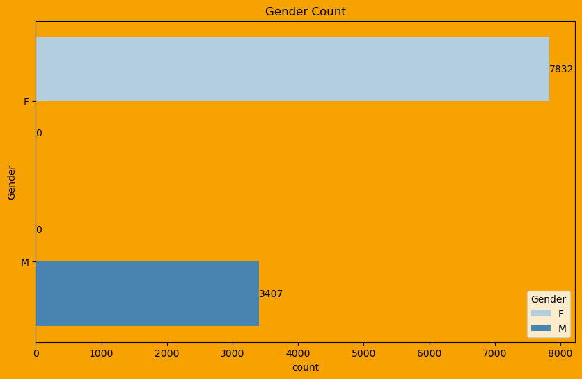

```python
# Setting up the figure size and background color
plt.figure(figsize=(10, 6), facecolor='#F7A200')

# Setting the title of the plot
plt.title('Gender Count')

# Creating a count plot for gender using seaborn
a = sns.countplot(y='Gender', hue='Gender', data=flip_kart_df, palette='Blues')

# Setting the background color of the plot
a.patch.set_facecolor('#F7A200')

# Adding labels to the bars
for bars in a.containers:
    a.bar_label(bars)
```

- The bar chart provides a visual representation of the gender distribution within the dataset. It reveals that females constitute a significant majority, with 7832 individuals, while males account for 3407 individuals, indicating a noticeable gender imbalance in the dataset.
- This gender disparity could have implications for targeted marketing strategies, product recommendations, or understanding customer preferences, emphasizing the importance of considering gender-specific trends in further analysis.

## Total Sales by Gender: Pie Chart

In this section, we visualize the distribution of total sales by gender using a pie chart to understand the contribution of each gender category to the overall sales.

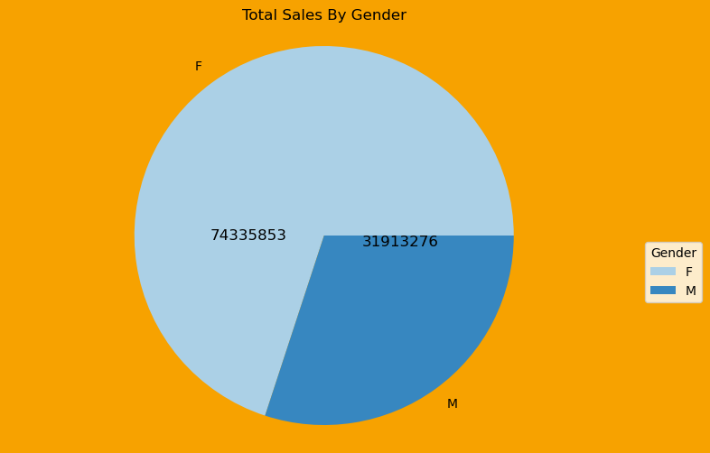

```python
# Calculating total sales by gender
sales_gender = flip_kart_df.groupby(['Gender'], as_index=False)['Amount'].sum()

# Generating colors for the pie chart
colors = sns.color_palette('Blues', n_colors=len(sales_gender))

# Setting up the figure size and background color
plt.figure(figsize=(9, 6), facecolor='#F7A200')
plt.title('Total Sales By Gender')

# Creating the pie chart
patches, texts, autotexts = plt.pie(sales_gender['Amount'], labels=sales_gender['Gender'], autopct='', colors=colors, pctdistance=0.7)
plt.axis('equal')

# Adding text labels for sales amounts
female_sales = sales_gender[sales_gender['Gender'] == 'F']['Amount'].values[0]
male_sales = sales_gender[sales_gender['Gender'] == 'M']['Amount'].values[0]
plt.text(-0.4, 0, f"{female_sales}", fontsize=12, ha='center', va='center', color='black')
plt.text(0.4, 0, f"{male_sales}", fontsize=12, ha='center', va='top', color='black')

# Adding legend
plt.legend(title='Gender', loc='upper left', bbox_to_anchor=(1, 0.5))
```

- The pie chart depicting total sales by gender reaffirms the observation from the previous bar chart that the majority of buyers are females.
- Moreover, the purchasing power of females appears to surpass that of males, as indicated by the larger sales amount attributed to the female category.

## Age Group Analysis: Count Variation

In this section, we explore how the counts vary across different age groups. We visualize this variation using a bar chart to understand the distribution of counts across age groups, with a further breakdown by gender.

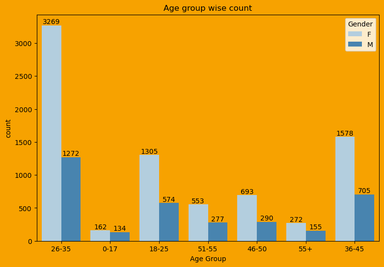

```python
# Setting up the figure size and background color
plt.figure(figsize=(9, 6), facecolor='#F7A200')
plt.title('Age group wise count')

# Creating a count plot for age groups with gender breakdown using seaborn
a = sns.countplot(data=flip_kart_df, x='Age Group', hue='Gender', palette='Blues')

# Setting the background color of the plot
a.patch.set_facecolor('#F7A200')

# Turning off the grid lines
a.grid(False)

# Adding labels to the bars
for bars in a.containers:
    a.bar_label(bars)
```

- The age group of 26-35 emerges as the most prominent demographic segment in the dataset, with the highest counts recorded for both females and males. This indicates a significant portion of the customer base falls within this age range, suggesting a prime target for marketing campaigns or product offerings.
- Understanding the preferences and behaviors of customers within this age group could provide valuable insights for tailoring marketing strategies or developing products/services that resonate with this demographic, potentially leading to increased customer engagement and sales.

## Correlation Analysis: Age Groups and Total Amount Spent

In this section, we investigate whether there is a correlation between age groups and the total amount spent. We visualize this relationship using a bar chart to understand how the total amount spent varies across different age groups.

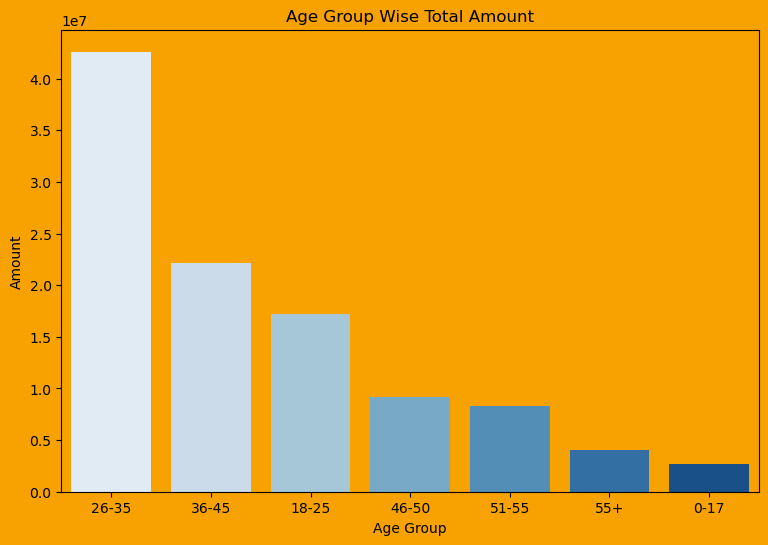

```python
# Setting up the figure size and background color
plt.figure(figsize=(9, 6), facecolor='#F7A200')
plt.title('Age Group Wise Total Amount')

# Calculating total amount spent by each age group
sales_age_group = flip_kart_df.groupby(['Age Group'], as_index=False)['Amount'].sum().sort_values(by='Amount', ascending=False)

# Creating a bar plot for total amount spent by age group using seaborn
a = sns.barplot(x='Age Group', y='Amount', data=sales_age_group, palette='Blues', errorbar=None)

# Setting the background color of the plot
a.patch.set_facecolor('#f7a200')

# Turning off the grid lines
a.grid(False)
```

The visualization highlights the significant contribution of the age group 26-35 years to the total amount spent, suggesting a strong correlation between this demographic and purchasing behavior. This underscores the importance of targeting marketing efforts towards this age group and tailoring product offerings to meet their preferences and needs. Understanding the specific preferences and spending habits of customers within the 26-35 age range can provide valuable insights for optimizing marketing strategies, product development, and customer engagement initiatives, ultimately leading to enhanced sales and customer satisfaction.

## Distribution of Orders Across Top 10 States

In this section, we analyze the distribution of orders across the top 10 states. We visualize this distribution using a line plot to understand the variation in total orders across different states.

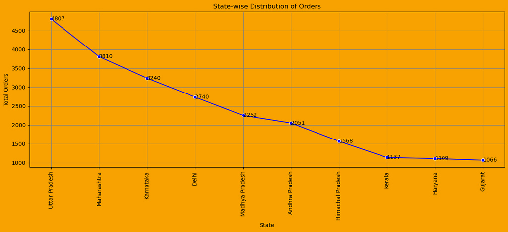

```python
# Setting up the figure size and background color
plt.figure(figsize=(13, 6), facecolor='#F7A200')
plt.title('State-wise Distribution of Orders')

# Calculating total orders for the top 10 states
orders_state = flip_kart_df.groupby(['State'], as_index=False)['Orders'].sum().sort_values(by='Orders', ascending=False).head(10)

# Creating a line plot for state-wise distribution of orders using seaborn
a = sns.lineplot(data=orders_state, y='Orders', x='State', marker='o', color='blue')

# Setting the background color of the plot
a.patch.set_facecolor('#F7A200')

# Turning on the grid lines and setting the color
a.grid(True, color='gray')

# Adding labels to the data points
for index, row in orders_state.iterrows():
    a.text(row['State'], row['Orders'], f'{row["Orders"]}', color='black', ha='left', va='center')

# Setting labels and formatting
plt.xlabel('State')
plt.ylabel('Total Orders')
plt.xticks(rotation=90)
plt.tight_layout()
```

- UP emerges as the dominant market among the top 10 states, with the highest number of orders recorded at 4807. This indicates a strong demand or sales volume in UP, suggesting potential opportunities for business expansion or targeted marketing efforts to capitalize on this lucrative market.
- Exploring the factors driving the high demand in UP can provide valuable insights for optimizing supply chain management, inventory planning, and marketing strategies. Moreover, focusing on enhancing customer satisfaction and loyalty in this key market can contribute to long-term business growth and competitiveness.

## Distribution of Total Sales Across Top 10 States

In this section, we explore the distribution of total sales across the top 10 states. We visualize this distribution using a bar plot to understand the contribution of each state to the overall sales.

[figure not shown]

```python
import matplotlib.pyplot as plt
import seaborn as sns

# Setting up the figure size and background color
plt.figure(figsize=(10, 6), facecolor='#F7A200')

# Setting the title of the plot
plt.title('Total Sales Distribution by States')

# Calculating total sales for the top 10 states
sales_state = flip_kart_df.groupby(['State'], as_index=False)['Amount'].sum().sort_values(by='Amount', ascending=False).head(10)

# Creating a bar plot for total sales distribution by states using seaborn
a = sns.barplot(data=sales_state, x='State', y='Amount', palette='Blues')

# Setting the background color of the plot
a.patch.set_facecolor('#F7A200')

# Turning off the grid lines
a.grid(False)

# Rotating x-axis labels for better readability
plt.xticks(rotation=90)

# Adding labels to the bars
for index, row in sales_state.iterrows():
    a.text(index, row['Amount'], str(round(row['Amount'], 2)), color='black', ha="center")

plt.show()
```

The analysis highlights Uttar Pradesh, Maharashtra, and Karnataka as the top contributing states in terms of both orders and total sales, indicating their significant importance to the business. Understanding the dominance of these states in driving sales can inform strategic decisions related to resource allocation, marketing campaigns, and expansion efforts, enabling businesses to prioritize these regions for growth opportunities. By focusing on strengthening market presence and customer relationships in Uttar Pradesh, Maharashtra, and Karnataka, businesses can effectively capitalize on the high demand and sales potential within these key markets, ultimately driving sustainable business growth.

## Top 5 Customers by Sales in Different States

In this section, we identify the top 5 customers by sales in different states. We visualize this information using grouped bar charts to understand the distribution of sales among the top customers across various states

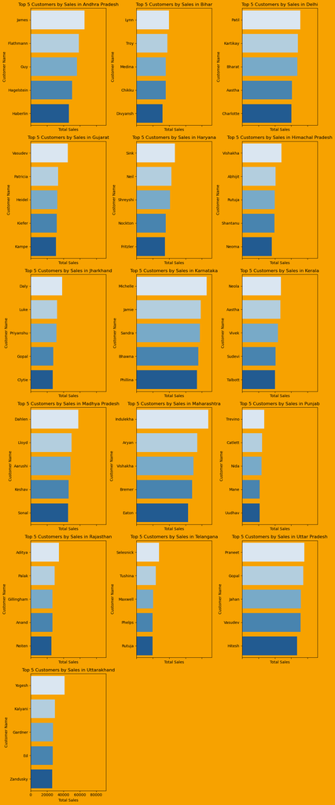

```python
# Calculating sales by customer in each state
sales_by_customer = flip_kart_df.groupby(['State', 'Customer_name'])['Amount'].sum().reset_index()

# Sorting the data to find the top 5 customers by sales in each state
sales_by_customer_sorted = sales_by_customer.groupby('State').apply(lambda x: x.nlargest(5, 'Amount')).reset_index(drop=True)

# Extracting unique states
states = sales_by_customer_sorted['State'].unique()
num_states = len(states)

# Determining the number of rows for subplots
num_rows = (num_states + 2) // 3

# Creating subplots
fig, axes = plt.subplots(num_rows, 3, figsize=(12, 5*num_rows), sharex=True, facecolor='#F7A200')
fig.patch.set_facecolor('#F7A200')

# Defining colors for the bar plots
colors = sns.color_palette('Blues', n_colors=5)

# Iterating through states and plotting
for i, state in enumerate(states):
    row = i // 3
    col = i % 3

    data = sales_by_customer_sorted[sales_by_customer_sorted['State'] == state]

    ax = sns.barplot(x='Amount', y='Customer_name', hue='Customer_name', data=data, ax=axes[row, col], palette=colors, dodge=False)

    ax.set_title(f'Top 5 Customers by Sales in {state}')
    ax.set_xlabel('Total Sales')
    ax.set_ylabel('Customer Name')
    ax.set_facecolor('#F7A200')

    if ax.legend_:
        ax.legend_.remove()

# Removing unused subplots
for i in range(num_states, num_rows*3):
    fig.delaxes(axes.flatten()[i])

plt.tight_layout()
```

Analyzing the top 5 customers by sales across states offers valuable insights into regional buying patterns and customer loyalty, highlighting the key players driving sales within each area. By identifying the top customers in different states, businesses can tailor marketing strategies and customer engagement efforts to nurture relationships with these high-value customers, potentially increasing retention and fostering brand advocacy. Additionally, understanding the preferences and behaviors of top customers in various regions can inform product assortment decisions and personalized marketing initiatives, enabling businesses to meet customer needs more effectively and drive sustainable growth.

# Distribution of Marital Status Among Customers¶

In this section, we explore the distribution of marital status among customers. We visualize this distribution using a pie chart to understand the proportion of married and unmarried customers within the dataset.

```
(-1.1, 1.1, -1.1, 1.1)
```

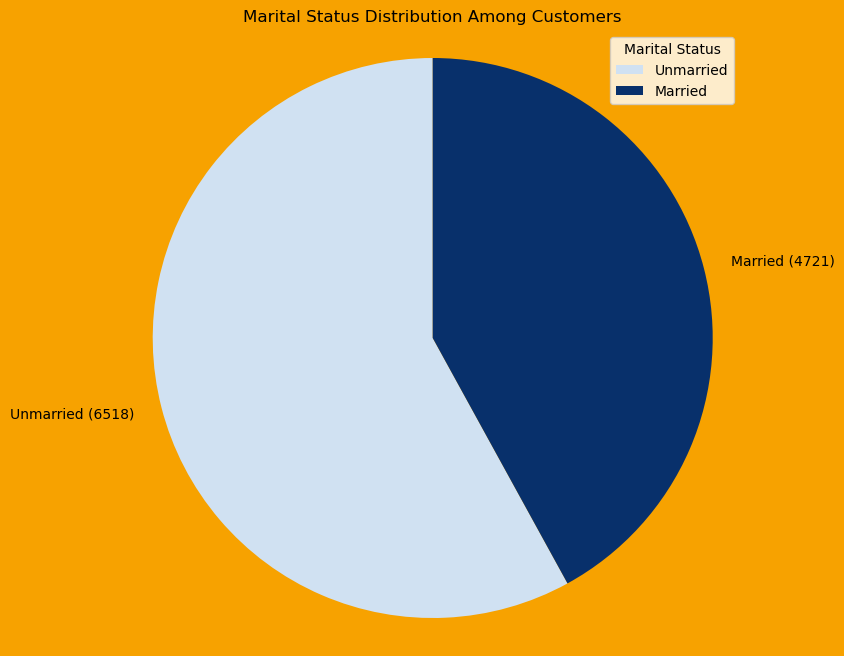

```python
# Setting up the figure size and background color
plt.figure(figsize=(8, 8), facecolor='#F7A200')

# Setting the title of the plot
plt.title('Marital Status Distribution Among Customers')

# Counting the occurrences of each marital status
marital_counts = flip_kart_df['Marital_Status'].value_counts()

# Renaming index labels for better readability
marital_counts.index = ['Unmarried', 'Married']

# Generating colors for the pie chart
colors = plt.cm.Blues(np.linspace(0.2, 1, len(marital_counts)))

# Creating a pie chart for marital status distribution
pie = plt.pie(marital_counts, labels=[f'{label} ({count})' for label, count in marital_counts.items()], colors=colors, startangle=90)

# Adding legend and setting its title and labels
plt.legend(title='Marital Status', labels=['Unmarried', 'Married'], loc='upper right')

# Setting the limits of the plot
plt.axis((-1.1, 1.1, -1.1, 1.1))
```

- The pie chart reveals that there are 6,518 unmarried customers and 4,721 married customers, indicating a larger proportion of unmarried individuals within the customer base compared to married individuals.
- Understanding the predominance of unmarried customers can inform marketing strategies and product offerings tailored to this demographic, potentially enhancing customer engagement and satisfaction.
- Targeted campaigns or promotions aimed at unmarried customers may capitalize on their larger representation in the customer base, leading to increased sales and brand loyalty.

## Sales Distribution by Marital Status

In this section, we analyze the distribution of sales based on marital status. We visualize this distribution using a bar plot to understand how sales vary between married and unmarried customers.

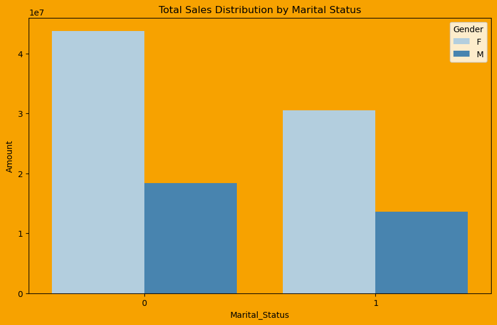

```python
# Setting up the figure size and background color
plt.figure(figsize=(10,6), facecolor='#F7A200')

# Setting the title of the plot
plt.title('Total Sales Distribution by Marital Status')

# Calculating total sales by marital status and gender
sales_marital = flip_kart_df.groupby(['Marital_Status', 'Gender'], as_index=False)['Amount'].sum().sort_values(by='Amount', ascending=False)

# Creating a bar plot for sales distribution by marital status using seaborn
a = sns.barplot(data=sales_marital, x='Marital_Status', y='Amount', hue='Gender', palette=('Blues'))

# Turning off the grid lines
a.grid(False)

# Setting the background color of the plot
a.patch.set_facecolor('#F7A200')
```

- The visualization indicates a significant presence of unmarried female buyers, highlighting their substantial purchasing influence within the dataset.
- Recognizing the purchasing power of unmarried female buyers presents an opportunity for businesses to develop inclusive marketing strategies and product offerings that resonate with this influential demographic, fostering greater sales and customer satisfaction.

## Distribution of Customers Across Occupations

In this section, we explore the distribution of customers across different occupations. We visualize this distribution using a horizontal bar plot to understand the representation of various occupations within the customer base.

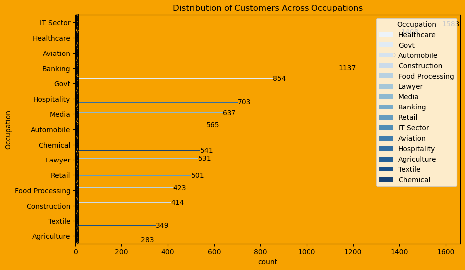

```python
import matplotlib.pyplot as plt
import seaborn as sns

# Setting up the figure size and background color
plt.figure(figsize=(10, 6), facecolor='#F7A200')

# Setting the title of the plot
plt.title('Distribution of Customers Across Occupations')

# Creating a count plot for the distribution of customers across occupations using seaborn
a = sns.countplot(data=flip_kart_df, y='Occupation', hue='Occupation', palette='Blues', order=flip_kart_df['Occupation'].value_counts().index)

# Turning off the grid lines
a.grid(False)

# Setting the background color of the plot
a.patch.set_facecolor('#F7A200')

# Adding labels to the bars
for bars in a.containers:
    a.bar_label(bars)

# Adding legend
plt.legend(title='Occupation', loc='upper right')

plt.show()
```

## Distribution of Sales Across Different Occupations

In this section, we examine the distribution of sales across different occupations. We visualize this distribution using a bar plot to understand how sales vary among various occupation categories.

[output not shown]

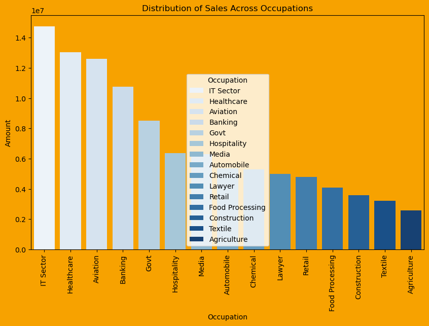

```python
# Setting up the figure size and background color
plt.figure(figsize=(10,6), facecolor='#f7a200')

# Setting the title of the plot
plt.title('Distribution of Sales Across Occupations')

# Calculating total sales by occupation
sales_occupation = flip_kart_df.groupby(['Occupation'], as_index=False)['Amount'].sum().sort_values(by='Amount', ascending=False)

# Creating a bar plot for sales distribution by occupation using seaborn
a = sns.barplot(data=sales_occupation, x='Occupation', y='Amount', palette='Blues', hue='Occupation', dodge=False)

# Turning off the grid lines
a.grid(False)

# Setting the background color of the plot
a.patch.set_facecolor('#f7a200')

# Rotating x-axis labels for better readability
plt.xticks(rotation=90)
```

The charts highlight a significant proportion of buyers employed in the IT, healthcare, and aviation sectors, indicating substantial sales generated from these industries. To capitalize on this trend, businesses should develop targeted marketing campaigns and tailored product offerings to cater to the specific needs and preferences of customers within these sectors. Conversely, the agriculture sector exhibits the lowest total sales, suggesting limited purchasing activity within this industry compared to others. Businesses operating in this sector may benefit from exploring opportunities for diversification or innovation to attract and engage customers more effectively. This could involve partnerships, product differentiation, or the introduction of value-added services. Continuous monitoring and analysis of sales distribution across different occupations can provide valuable insights for strategic decision-making. By adapting approaches and allocating resources more efficiently based on these insights, businesses can maximize sales and drive sustainable growth.

## Distribution of Product Count by Category

In this section, we explore the distribution of product count by category. We visualize this distribution using a horizontal bar plot to understand the representation of different product categories within the dataset

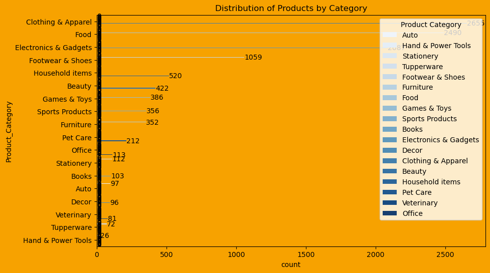

```python
import matplotlib.pyplot as plt
import seaborn as sns

# Setting up the figure size and background color
plt.figure(figsize=(10, 6), facecolor='#F7A200')

# Setting the title of the plot
plt.title('Distribution of Products by Category')

# Creating a count plot for the distribution of products by category using seaborn
a = sns.countplot(data=flip_kart_df, y='Product_Category', hue='Product_Category', palette='Blues', order=flip_kart_df['Product_Category'].value_counts().index)

# Turning off the grid lines
a.grid(False)

# Setting the background color of the plot
a.patch.set_facecolor('#F7A200')

# Adding labels to the bars
for bars in a.containers:
    a.bar_label(bars)

# Adding legend
plt.legend(title='Product Category', loc='upper right')

plt.show()
```

Clothing and apparel emerge as the most frequently purchased category, with 2655 units sold, followed by food and electronic gadgets, indicating consumer preferences and potentially lucrative market segments within the dataset. To capitalize on the popularity of these categories, businesses can enhance their product offerings, optimize marketing strategies, and prioritize inventory management to meet customer demand effectively. Conversely, hand and power tools exhibit the lowest sales volume, with only 26 units sold, suggesting limited consumer interest or market demand for this category. Businesses operating in this sector may consider evaluating their product range, exploring opportunities for product diversification or enhancements, and implementing targeted promotional campaigns to stimulate sales and attract customers. Continuous monitoring and analysis of product count distribution by category can provide valuable insights for strategic decision-making and product development. By understanding consumer preferences and market trends, businesses can adapt their strategies, innovate their offerings, and stay competitive in the dynamic retail landscape, ultimately driving business growth and profitability.

## Distribution of Sales Across Product Categories

In this analysis, we examine the distribution of sales across different product categories. By visualizing the total sales generated by the top 10 product categories, we gain insights into the sales performance of various product categories within the dataset. These insights can inform strategic decision-making and marketing strategies, helping businesses identify high-performing product categories and areas for potential growth or optimization.

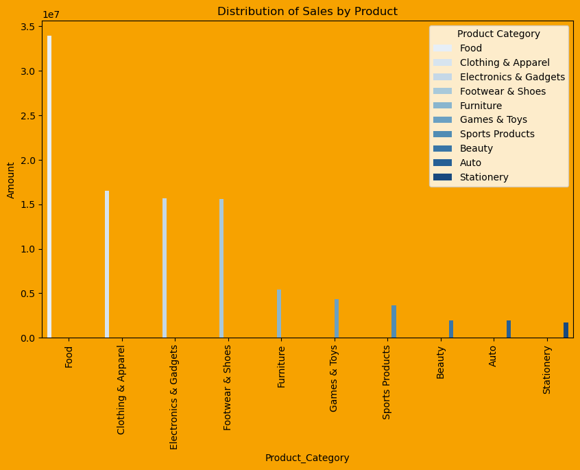

```python
import matplotlib.pyplot as plt
import seaborn as sns

# Calculating the top 10 product categories by total sales
sales_product = flip_kart_df.groupby(['Product_Category'], as_index=False)['Amount'].sum().sort_values(by='Amount', ascending=False).head(10)

# Calculating the number of unique product categories
num_categories = len(sales_product['Product_Category'].unique())

# Generating a color palette for the plot
palette = sns.color_palette("Blues", n_colors=num_categories)

# Setting up the figure size and background color
plt.figure(figsize=(10,6), facecolor='#F7A200')
plt.title('Distribution of Sales by Product')

# Creating a bar plot for the distribution of sales by product using seaborn
a = sns.barplot(data=sales_product, x='Product_Category', y='Amount', hue='Product_Category', palette='Blues')

# Turning off the grid lines
a.grid(False)

# Setting the background color of the plot
a.patch.set_facecolor('#F7A200')

# Rotating x-axis labels for better readability
plt.xticks(rotation=90)

# Adding legend
plt.legend(title='Product Category', loc='upper right')

plt.show()
```

Understanding the popularity and sales performance of different product categories can guide businesses in making informed decisions about inventory management, pricing strategies, and marketing campaigns. By allocating resources and efforts strategically, businesses can maximize sales opportunities within high-performing categories while also exploring avenues for improving sales in underperforming categories.

Continuous monitoring and analysis of sales distribution across product categories are essential for identifying market trends, consumer preferences, and emerging opportunities. By staying attentive to shifts in consumer behavior and market dynamics, businesses can adapt their strategies proactively, innovate their offerings, and maintain a competitive edge in the retail landscape, ultimately driving business growth and profitability.

## Top 5 Product Categories by Sales in Different States

In this analysis, we identify the top 5 product categories by sales in different states. By visualizing the total sales of each product category within the dataset, segmented by state, we gain insights into regional sales trends and consumer preferences. This analysis helps businesses understand which product categories perform best in each state, allowing for targeted marketing efforts and inventory management strategies.

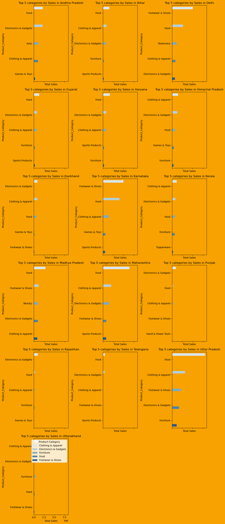

```python
import matplotlib.pyplot as plt
import seaborn as sns

# Calculating total sales by product category in each state
sales_by_product = flip_kart_df.groupby(['State', 'Product_Category'])['Amount'].sum().reset_index()

# Sorting the data to find the top 5 product categories by sales in each state
sales_by_product_sorted = sales_by_product.groupby('State').apply(lambda x: x.nlargest(5, 'Amount')).reset_index(drop=True)

# Extracting unique states and calculating the number of rows needed for subplots
states = sales_by_product_sorted['State'].unique()
num_states = len(states)
num_rows = (num_states + 2) // 3

# Creating subplots for visualization
fig, axes = plt.subplots(num_rows, 3, figsize=(12, 5*num_rows), sharex=True, facecolor='yellow')
fig.patch.set_facecolor('#F7A200')

# Iterating over states to plot top 5 product categories by sales
for i, state in enumerate(states):
    row = i // 3
    col = i % 3
    data = sales_by_product_sorted[sales_by_product_sorted['State'] == state]

    ax = sns.barplot(x='Amount', y='Product_Category', data=data, ax=axes[row, col], palette='Blues', hue='Product_Category')

    ax.set_title(f'Top 5 categories by Sales in {state}')
    ax.set_xlabel('Total Sales')
    ax.set_ylabel('Product_Category')
    ax.set_facecolor('#F7A200')

    # Removing legend for each subplot
    ax.get_legend().remove()

# Removing excess subplots if necessary
for i in range(num_states, num_rows*3):
    fig.delaxes(axes.flatten()[i])

plt.tight_layout()
plt.legend(title='Product Category', loc='upper right')
plt.show()
```

Examining the top 5 product categories by sales across states provides valuable insights into consumer preferences and regional market dynamics. It showcases which product categories are most popular and profitable in different regions, reflecting both cultural influences and economic factors.

Based on these insights, businesses can tailor their marketing strategies and product offerings to align with the preferences of consumers in each state. By understanding regional variations in demand, businesses can optimize their inventory management, target advertising campaigns effectively, and capitalize on emerging market trends to drive sales growth and enhance customer satisfaction.

Continuous monitoring of sales performance across different product categories and states enables businesses to adapt quickly to changing market conditions and consumer behavior. By leveraging data-driven insights, businesses can make informed decisions, identify opportunities for expansion, and stay competitive in the dynamic retail landscape, ultimately fostering long-term success and profitability.

## Gender Distribution Across Different States

In this analysis, we explore how the gender distribution varies across different states. By visualizing the number of customers by gender in each state, we gain insights into regional gender demographics and potential variations in consumer behavior. This analysis helps businesses understand the gender composition of their customer base in different regions, enabling targeted marketing efforts and tailored product offerings.

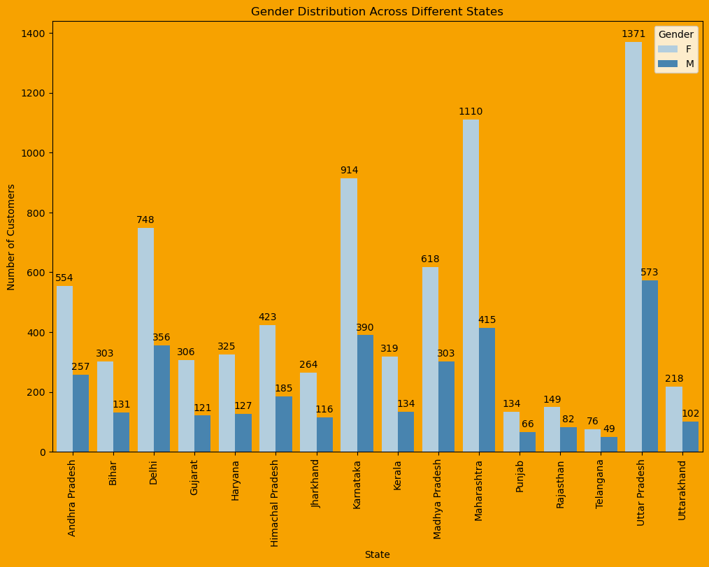

```python
# Calculating gender distribution across different states
gender_distribution = flip_kart_df.groupby(['State', 'Gender']).size().reset_index(name='Count')

# Setting up the figure size and background color
plt.figure(figsize=(12, 8), facecolor='#f7a200')
plt.title('Gender Distribution Across Different States')

# Creating a bar plot for gender distribution across states using seaborn
ax = sns.barplot(data=gender_distribution, x='State', y='Count', hue='Gender', palette='Blues')

# Setting labels and formatting
plt.xlabel('State')
plt.ylabel('Number of Customers')
plt.grid(False)
plt.gca().patch.set_facecolor('#f7a200')
plt.legend(title='Gender', loc='upper right')
plt.xticks(rotation=90)

# Adding labels to the bars
for p in ax.patches:
    ax.annotate(f'{p.get_height():.0f}',
                (p.get_x() + p.get_width() / 2., p.get_height()),
                ha='center',
                va='baseline',
                xytext=(0, 5),
                textcoords='offset points')
```

- The insight from the chart indicates that across various states, there's a consistent trend of a higher proportion of female customers compared to male customers. This could suggest potential opportunities for targeted marketing strategies tailored towards female demographics in these states.
- Based on these insights, businesses can develop marketing campaigns and product offerings specifically designed to appeal to female consumers in states where they represent a significant portion of the customer base. By understanding and catering to the unique preferences and needs of female demographics, businesses can enhance customer engagement, drive sales growth, and build brand loyalty effectively.
- Continuous monitoring of gender distribution across different states allows businesses to adapt their strategies and offerings in response to changing market dynamics and consumer preferences. By leveraging data-driven insights and adopting a customer-centric approach, businesses can strengthen their competitive position, foster long-term customer relationships, and drive sustainable business success.

## Gender Distribution by Product Category

In this analysis, we investigate whether there are any **noticeable patterns** in the gender distribution based on product categories. By visualizing the number of customers by gender within each product category, we aim to identify any significant differences or trends in consumer behavior across different product segments.

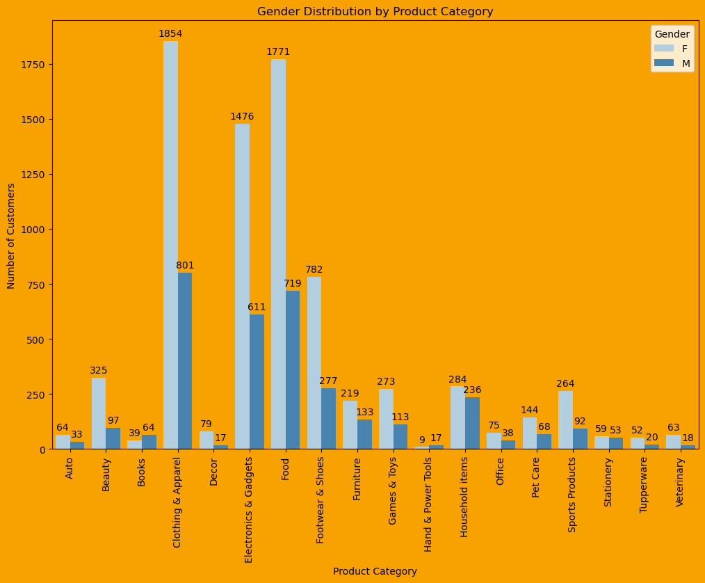

```python
# Calculating gender distribution by product category
gender_by_category = flip_kart_df.groupby(['Product_Category', 'Gender']).size().reset_index(name='Count')

# Setting up the figure size and background color
plt.figure(figsize=(12, 8), facecolor='#f7a200')
plt.title('Gender Distribution by Product Category')

# Creating a color palette for the genders
palette = sns.color_palette("Blues", n_colors=len(gender_by_category['Gender'].unique()))

# Creating a bar plot for gender distribution by product category using seaborn
ax = sns.barplot(data=gender_by_category, x='Product_Category', y='Count', hue='Gender', palette=palette)

# Setting labels and formatting
plt.xlabel('Product Category')
plt.ylabel('Number of Customers')
plt.grid(False)
plt.gca().patch.set_facecolor('#f7a200')
plt.legend(title='Gender', loc='upper right')
plt.xticks(rotation=90)

# Adding labels to the bars
for p in ax.patches:
    ax.annotate(f'{p.get_height():.0f}',
                (p.get_x() + p.get_width() / 2., p.get_height()),
                ha='center',
                va='baseline',
                xytext=(0, 5),
                textcoords='offset points')
```

# CONCLUSION

In this extensive analysis of Flipkart sales data, we conducted a thorough examination of various dimensions of consumer behavior and market trends. Through meticulous data preparation and in-depth exploration, we uncovered valuable insights that can inform strategic decision-making and drive business growth in the e-commerce sector.

### KEY INSIGHTS

- **Gender Distribution:** Our analysis revealed a prevalent trend of female dominance across multiple product categories, indicating significant opportunities for targeted marketing and product development strategies tailored to female consumers.
- **Age Demographics:** By analyzing sales performance across different age groups, we identified specific age cohorts, such as the 26-35 age group, contributing significantly to total sales, highlighting the importance of understanding demographic preferences in marketing efforts.
- **Product Preferences:** Detailed examination of product category sales patterns unveiled distinct preferences among male and female consumers, with certain categories, like clothing and electronics, attracting a higher proportion of female customers, while others, such as hand and power tools, appealed predominantly to male consumers.
- **Regional Variations:** Our analysis also uncovered variations in sales performance across different states, with Uttar Pradesh emerging as a key market with the highest number of orders. Understanding regional dynamics is crucial for tailoring marketing strategies to local preferences and maximizing sales potential.

### STRATEGIC IMPLICATIONS

- **Targeted Marketing:** The insights gleaned from our analysis provide actionable intelligence for crafting targeted marketing campaigns that resonate with specific demographic segments and regional preferences, thereby enhancing customer engagement and driving sales growth.
- **Product Assortment Optimization:** Businesses can leverage the identified product preferences to optimize their product assortments, ensuring alignment with consumer demand and enhancing overall customer satisfaction and retention.
- **Competitive Advantage:** By harnessing data-driven insights, Flipkart and other e-commerce businesses can gain a competitive edge in the dynamic marketplace, fostering innovation, and agility in response to evolving consumer trends and preferences.

In conclusion, our analysis serves as a valuable resource for stakeholders in the e-commerce industry, offering actionable insights to guide strategic decision-making and capitalize on emerging market opportunities. By leveraging data analytics, businesses can navigate the complexities of the online retail landscape with confidence and drive sustainable growth and profitability.